# My Spotify Listening Habits

## Introduction: What is this data?

This data story is based on my personal music listening habits. Over a period of several days, I observed and logged each of my Spotify listening sessions using a Google Form I created. For every session, I recorded the duration (in minutes), music genre, device used, and what I was doing while listening. I also captured the timestamp so I could analyse patterns over time.

Using this self-collected data, I explored three questions:

1. Which music genres do I spend the most time listening to?
2. What activities do I tend to pair with listening to music?
3. Are there patterns in my listening sessions across the week?

## What genres take up the most of my time?

Some genres clearly dominate my listening time. This chart shows the average number of minutes I spent listening to each genre.

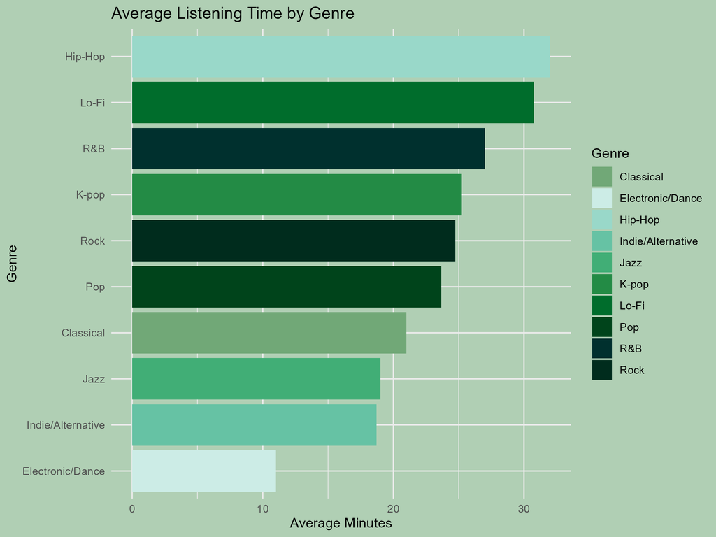

This bar chart shows the average number of minutes I spent listening to each genre across all sessions.

Hip-Hop and Lo-Fi had the highest average listening times, which may reflect their use during long, focused activities like gaming or studying.

Genres like R&B, K-pop, and Rock also showed relatively high engagement, possibly due to their upbeat and engaging nature.

Electronic/Dance music had the lowest average listening time, which might be due to its use in shorter sessions, such as during quick workouts.

The wide range of genres suggests a diverse music preference, though clearly skewed toward certain styles.

This plot gives a clear view of what genres dominate my listening time overall.

## What am I doing while I listen?

This boxplot reveals how my activities affect the duration of my listening sessions.

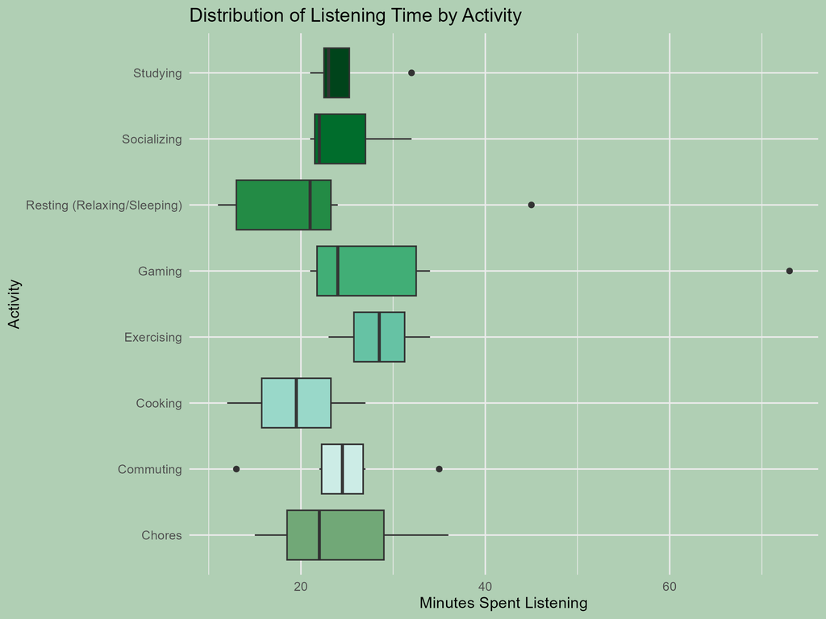

This boxplot presents the distribution of listening durations grouped by activity.

Gaming and Resting have the widest spread in listening times, indicating that these activities vary significantly in length and are often accompanied by music.

Studying, Socializing, and Exercising tend to have tighter ranges, possibly reflecting more routine durations for these activities.

Outliers (dots) show that sometimes I listened much longer or shorter than typical for that activity - for example, long sessions while gaming or resting.

This plot emphasizes that the context of the activity greatly affects how long I listen to music.

## Genre types throughout the week

This plot shows the genre types I listen to throughout the week. The “Mainstream” category combines the Pop, Rock, and Hip Hop genres, while the “Other” category encompasses all other genres.

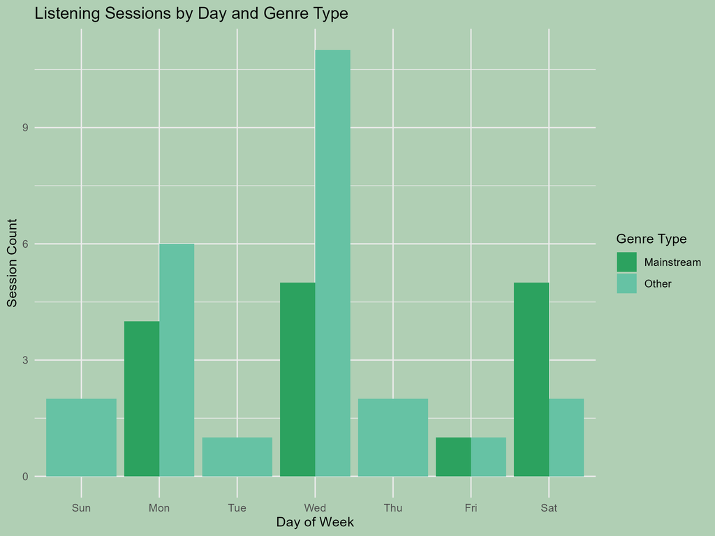

Bar chart of listening sessions per weekday by genre type

Wednesday has the highest number of sessions (16), with a significant majority of those sessions coming from “Other” genres. This suggests that mid-week may be when I explore a wider range of music outside of mainstream genres.